# ЛР2_R_Вар3_Галимова_МС3

Аделя Галимова

2024-12-06

# Лабораторная работа в среде R

## по второму разделу “Проверка гипотез”

## Вариант 3

### Выполнила:

### Студентка БСТ233

### Галимова Аделя

# Раздел 2. Проверка гипотез

## 2.1 Тесты на однородность дисперсий независимых выборок.

Для начала работы необходимо взять данные из предыдущей части:

```r
getwd()
```

```
## [1] "C:/Users/evere/Desktop/matstat"
```

```r
setwd('C:\\Users\\evere\\Desktop\\matstat')
library('rio')
dataframe <- import('Данные по вариантам для выполнения типового расчета.xlsx')
data <- dataframe['v3']
data <- data[1:100,]
data <- as.data.frame(as.numeric(data))
```

Примем первые 50 наблюдений за переменную Х, а вторые 50 за переменную У, при $\alpha = 0.05$

```r
alpha <- 0.05 #заданный уровень значимости
x <- c(data[1:50,])
y <- c(data[51:100,])
```

Проведем тест Фишера для правосторонней критической области

```r
var.test(x,y, alternative = "greater")
```

```
##
##  F test to compare two variances
##
## data:  x and y
## F = 1.1317, num df = 49, denom df = 49, p-value = 0.3333
## alternative hypothesis: true ratio of variances is greater than 1
## 95 percent confidence interval:
##  0.7041112       Inf
## sample estimates:
## ratio of variances
##           1.131711
```

Мы получили $F_{набл} = 1.1317$, $p-value = 0.3333$ больше, чем $0,05$ => Гипотеза $H_{0}$ не отвергается, следовательно, на уровне значимости $\alpha = 0.05$ гипотеза о равенстве дисперсий генеральных совокупностей **не отвергается**.

*Это можно проверить с помощью $F_{крит}$ встроенной функцией **F-распределения***

```r
qf(alpha,49,49,lower.tail = FALSE)
```

```
## [1] 1.607289
```

Таким образом получаем:
$$F_{крит}=1.607289$$
$$F_{набл}=1.1317$$

*Так как $F_{набл}= 1.1317 < F_{крит}=1.607289$, то на уровне значимости $\alpha = 0.05$ можно считать, что гипотеза о равенстве дисперсий генеральных совокупностей также **не отвергается**.*

*Дополнительно используем непарметрический тест Fligner-Killeen test, очень устойчивый к отклонениям от нормальности.*

```r
fligner.test(x,y)
```

```
##
##  Fligner-Killeen test of homogeneity of variances
##
## data:  x and y
## Fligner-Killeen:med chi-squared = 7.4934, df = 13, p-value = 0.875
```

*$p$-$value = 0.875 > \alpha = 0.05$, то нулевая гипотеза $H_{0}$ **не отвергается**.*

## 2.2 Тесты на равенство средних

### 2.2.1 Сравнение среднего совокупности с заданным значением – параметрический тест (t-тест Стьюдента)

#### Проверка гипотезы о значении генеральной средней $$H_{0}: \mu = \mu_{0}$$ при неизвестной генеральной дисперсии $σ^2$ требует предварительной проверки выборки на нормальное распределение. Предположим, что наша выборка *x* извлечена из нормально распределенной генеральной совокупности $$x \in N(\mu_{x};\sigma_{x})$$

Проверим состав нашей переменной с помощью функции проверки целостности данных glimpse из пакета dplyr

```r
library(dplyr)
х <- c(data[1:50,])
glimpse(х)
```

```
##  num [1:50] 88 89 90 90 97 90 92 86 94 97 ...
```

```r
mean(х)
```

```
## [1] 90.26
```

#### Получаем среднее по выборке 90.26

#### Допустим, по нормативу среднее значение Х должно составлять 91. Таким образом, по имеющейся в нашем распоряжении выборке необходимо проверить нулевую гипотезу: $H_{0}$:𝜇 = 91

Проведем тест на проверку равенства средней нормативу.

```r
t.test(x,mu = 91)
```

```
##
##  One Sample t-test
##
## data:  x
## t = -1.0888, df = 49, p-value = 0.2816
## alternative hypothesis: true mean is not equal to 91
## 95 percent confidence interval:
##  88.89425 91.62575
## sample estimates:
## mean of x
##     90.26
```

#### Так как $p-value = 0.2816 > α=0,05$.Значит, гипотеза $H_{0}= 91$ не отвергается на уровне значимости 0,05.Средняя соответсвует нормативу. Наблюдаемое значение статистики критерия: t = -1.0888

#### Также значение норматива **91** содержится в построенном доверительном интервале для 𝜇 с надежностью **0,95**: 𝑃(88.89425 < 𝜇 < 91.62575) = 0.95

Чтобы вывести $t_{крит}$, можно воспользоваться встроенной функцией t-распределения Стьюдента, задаем в функции вероятность α/2:

```r
qt(alpha/2, 49)
```

```
## [1] -2.009575
```

### 2.2.2. Сравнение среднего выборки с заданным значением – **непараметрический тест Вилкоксона**

В случае отклонения распределения изучаемой совокупности от нормального для проверки гипотезы о равенстве средней определенному значению используется непараметрический **критерий Вилкоксона** и функция `wilcox.test`, устроенная аналогично функции `t.test`, попробуем воспользоваться ею для нашей выборки $X$, предположив, что распределение отклоняется от нормального:

```r
wilcox.test(x, mu = 91)
```

```
##
##  Wilcoxon signed rank test with continuity correction
##
## data:  x
## V = 539, p-value = 0.3423
## alternative hypothesis: true location is not equal to 91
```

### 2.2.3. Сравнение средних двух независимых нормально распределенных совокупностей – параметрический тест (t-тест Стьюдента)

#### После проведения теста на равенство дисперсий, можно провести тест на равенство средних в двух (независимых) выборках, извлеченных из нормальных совокупностей. В нем используется t-статистика Стьюдента.Выполнить этот тест можно с помощью уже знакомой нам функции t.test(). На входе функция получает две выборки — x и y — и два параметра: var.equal и paired. Первый из них отвечает за равенство дисперсий: var.equal = TRUE означает, что был проведён предыдущий тест и генеральные дисперсии неизвестны, но равны, вследствие чего будет использоваться t-тест Стьюдента.

```r
t.test(x,y,var.equal = TRUE, paired = FALSE)
```

```
##
##  Two Sample t-test
##
## data:  x and y
## t = 0.32163, df = 98, p-value = 0.7484
## alternative hypothesis: true difference in means is not equal to 0
## 95 percent confidence interval:
##  -1.551005  2.151005
## sample estimates:
## mean of x mean of y
##     90.26     89.96
```

Как можно видеть, $p-value = 0.7484 > α=0,05$. Значит, гипотеза *$H_{0}: 𝝁𝒙 = 𝝁𝒚$* не отвергается на уровне значимости 0,05.(средние двух совокупностей с большой долей вероятности равны). Наблюдаемое значение статистики критерия: $t_{набл} = 0.32163$.

#### Найдем $t_{крит}$:

```r
qt(0.975, 98)
```

```
## [1] 1.984467
```

#### Наблюдаемое значение статистики критерия: t_{набл} = 0.32163. Итак, |t_{набл}| = 0.32163 < t_{крит}= 1.984467, значит, гипотеза $$H_{0}: \mu_{x} = \mu_{y}$$ не отвергается на уровне значимости 0,05 (средние двух совокупностей с большой долей вероятности равны).

#### Теперь визуализируем сходство между средними с помощью ящичковых диаграмм:

```r
# Создадим таблицу из двух столбцов
my_data <- data.frame(
group = rep(c("x", "y"), each = 50),
something = c(x, y)
)
```

Посмотрим, что получилось:

```r
print(my_data)
```

```
##     group something
## 1       x        88
## 2       x        89
## 3       x        90
## 4       x        90
## 5       x        97
## 6       x        90
## 7       x        92
## 8       x        86
## 9       x        94
## 10      x        97
## 11      x        90
## 12      x        86
## 13      x        86
## 14      x        92
```

[output cut: 86 more lines]

#### Построим ящичковые диаграммы:

```r
library("ggpubr")
```

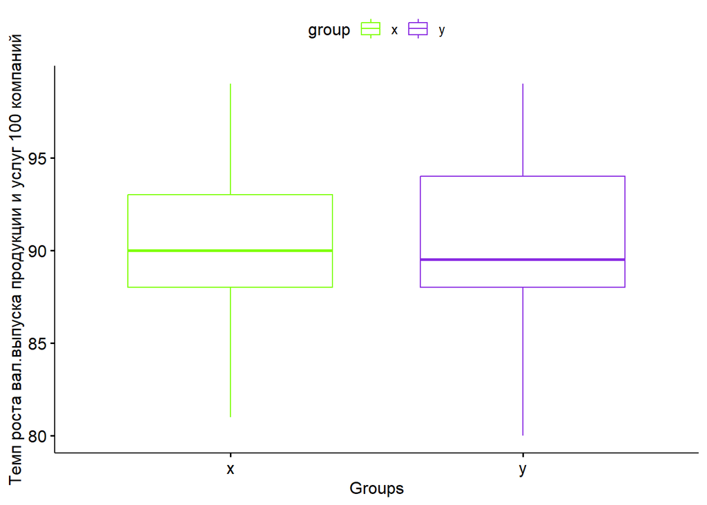

```r
ggboxplot(my_data, x = "group", y = "something",
color = "group", palette = c("chartreuse1", "blueviolet"),
ylab = "Темп роста вал.выпуска продукции и услуг 100 компаний", xlab = "Groups")
```

### 2.2.4. Сравнение различий двух совокупностей – непараметрический тест Вилкоксона

Для этих выборок посмотрим медианы, интерквартильные размахи и тест Вилкоксона для несвязных и связных выборок:

```r
median_x = median(x)
 median_x
```

```
## [1] 90
```

```r
 median_y = median(y)
 median_y
```

```
## [1] 89.5
```

```r
 IQR_x = IQR(x, na.rm = TRUE)
 IQR_y = IQR(y, na.rm = TRUE)
 IQR_x
```

```
## [1] 5
```

```r
 IQR_y
```

```
## [1] 6
```

```r
wilcox.test(x,y)
```

```
##
##  Wilcoxon rank sum test with continuity correction
##
## data:  x and y
## W = 1278.5, p-value = 0.8464
## alternative hypothesis: true location shift is not equal to 0
```

```r
wilcox.test(x,y, paired=TRUE)
```

```
##
##  Wilcoxon signed rank test with continuity correction
##
## data:  x and y
## V = 530.5, p-value = 0.6826
## alternative hypothesis: true location shift is not equal to 0
```

В обоих случаях получаются большие значения `p-value`: $0.8464$ и $0.6826$, следовательно, *нулевая гипотеза о незначимости различий между совокупностями не отвергается при $α=0,05$*.

## 2.3. Критерии проверки параметров биномиальных распределений

### 2.3.1.Тест на равенство вероятности успеха в испытании Бернулли определенной константе.

##### **Задача 6 из ДКР2 (5.108)**

> По разделу курса студенты решили верно 139 задач из 300 случайно отобранных для анализа. В предположении, что генеральная совокупность подчиняется биномиальному закону распределения, проверить на уровне значимости 0,01 следующие гипотезы:  
> а) Многолетняя практика показывает, что в среднем доля верно решённых разделов курса составляет 50 %. Можно ли считать полученные результаты согласующимися с этим утверждением? Или успеваемость упала? (проверить против двух соответствующих конкурирующих гипотез).  
> б) Сравнить долю решенных задач этого раздела с предыдущим, по которому студенты решили верно 115 задач из 200 случайно отобранных.

##### а) Многолетняя практика показывает, что в среднем доля верно решённых разделов курса составляет 50 %. Можно ли считать полученные результаты согласующимися с этим утверждением? Или успеваемость упала? (проверить против двух соответствующих конкурирующих гипотез).

$$n = 300, m=139$$
$$𝐻_{0}: 𝑝 = 𝑝_{0} = 0,5$$
$$𝐻_{1}: 𝑝 ≠ 𝑝_{0}$$

```r
prop.test(139,300,p=0.5)
```

```
##
##  1-sample proportions test with continuity correction
##
## data:  139 out of 300, null probability 0.5
## X-squared = 1.47, df = 1, p-value = 0.2253
## alternative hypothesis: true p is not equal to 0.5
## 95 percent confidence interval:
##  0.4060942 0.5215268
## sample estimates:
##         p
## 0.4633333
```

Без поправки Йетса:

```r
prop.test(139,300, p = 0.5, correct = FALSE)
```

```
##
##  1-sample proportions test without continuity correction
##
## data:  139 out of 300, null probability 0.5
## X-squared = 1.6133, df = 1, p-value = 0.204
## alternative hypothesis: true p is not equal to 0.5
## 95 percent confidence interval:
##  0.4077259 0.5198679
## sample estimates:
##         p
## 0.4633333
```

С поправкой $p-value = 0.2253> 0.01 = \alpha$, а без поправки $p-value=0.204 > 0.01 = \alpha$ , следовательно, гипотеза не отвергается в обоих случаях. *гипотеза $𝐻_{0}: 𝑝 = 𝑝_{0} = 0,5$ не отвергается на уровне значимости $\alpha = 0.01$.* Теперь применим точную формулу

```r
binom.test(139, 300, p = 0.5)
```

```
##
##  Exact binomial test
##
## data:  139 and 300
## number of successes = 139, number of trials = 300, p-value = 0.2253
## alternative hypothesis: true probability of success is not equal to 0.5
## 95 percent confidence interval:
##  0.4058477 0.5215501
## sample estimates:
## probability of success
##              0.4633333
```

### 2.3.2.Тест на равенство вероятностей успеха в испытаниях Бернулли для нескольких биномиально распределенных совокупностей

##### б) Сравнить долю решенных задач этого раздела с предыдущим, по которому студенты решили верно 115 задач из 200 случайно отобранных.

$$n_{1}=300, m_{1}=139, n_{2}=200,
m_{2}=115$$
$$H_{0}: 𝑝_{1} = 𝑝_{0}$$
$$𝐻_{1}: 𝑝_{1} ≠ 𝑝_{0}$$

```r
prop.test(x = c(139, 115), n = c(300, 200),correct = FALSE)
```

```
##
##  2-sample test for equality of proportions without continuity correction
##
## data:  c(139, 115) out of c(300, 200)
## X-squared = 5.9869, df = 1, p-value = 0.01441
## alternative hypothesis: two.sided
## 95 percent confidence interval:
##  -0.20042354 -0.02290979
## sample estimates:
##    prop 1    prop 2
## 0.4633333 0.5750000
```

```r
qchisq(0.99,1)
```

```
## [1] 6.634897
```

$\chi_{набл}^2 = 5.9869 < 6.634897 = \chi_{крит}^2$, $p-value = 0.01441 > 0.01 = \alpha$, следовательно, *нулевая гипотеза об однородности вероятностей не отвергается с вероятностью ошибки $0.01$, следовательно, доли решенных задач этого раздела с предыдущим равны*.

## 2.4. Критерии согласия эмпирического распределения с теоретическим*

### 2.4.1.Визуализация данных с целью подбора наилучшего теоретического распределения*

#### Прежде чем проверять выборочное эмпирическое распределение на согласие с каким-то теоретическим, необходимо понять, какое теоретическое распределение в принципе можно подобрать – по схожести гистограммы и функции плотности (вероятности) соответствующего распределения.

#### Как правило, отмечают графические методы как первое, самое простое и весьма эффективное средство проверки распределения на нормальность. И здесь основными методами являются: построение гистограмм и плотностей эмпирического распределения, ящичковых диаграмм, а также построение нормальных квантильных (`Q-Q plot`) и вероятностных (`P-P plot`) графиков.

#### Рассмотрим графики на данных из типового расчета. Для начала поместим их для удобства в вектор `volume`. Воспользуемся пакетом `ggpubr` еще раз для построения описанных графиков.

1. Построим эмпирическую плотность наших данных. По ее виду, как и по виду гистограммы, можно сделать вывод о предполагаемом теоретическом законе распределения.

```r
volume <- data[[1]]
library("ggpubr")
ggdensity(volume,
main = "Эмпирическая плотность темпа роста услуг 100 компаний",
xlab = "Темп роста (%) валового выпуска продукции и услуг")
```

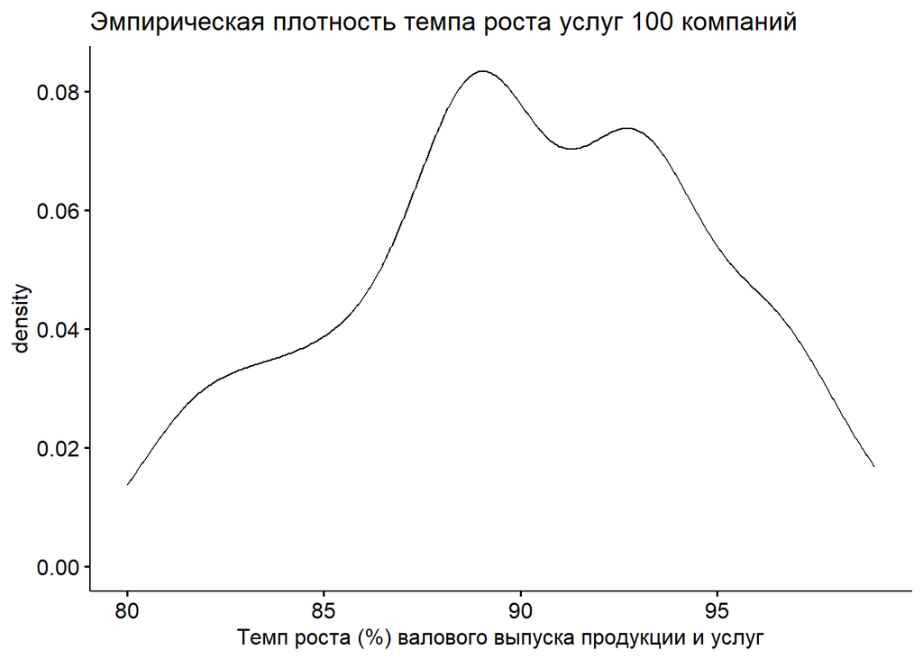

*Рис.5. Эмпирическая плотность темпа роста (%) валового выпуска продукции и услуг 100 комапний, построенная с помощью функции `ggdensity` пакета `ggpubr`*

2. Построим график типа квантиль-квантиль (`Q-Q plot`) для проверки соответствия квантилей выборки квантилям нормального распределения:

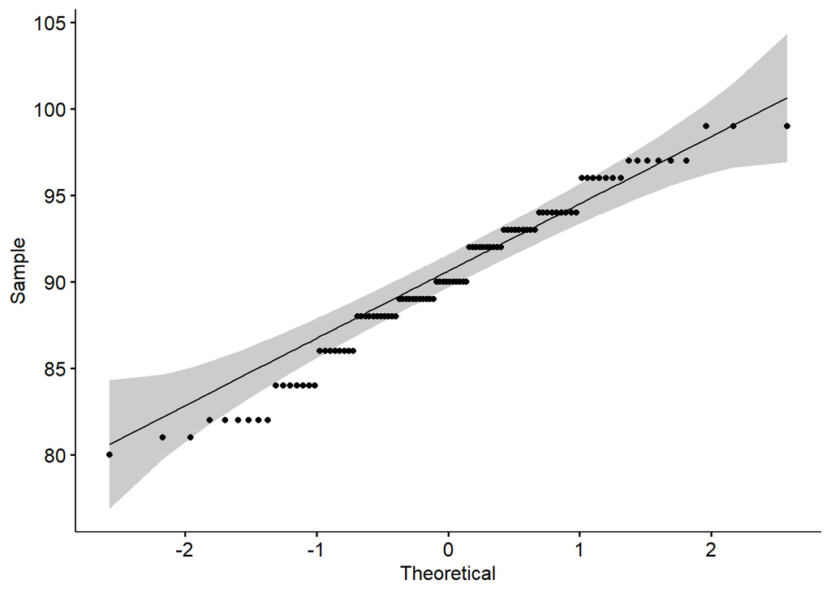

*Рис.6. Квантильный график (`Q-Q plot`) - эмпирическое распределение квантилей темпов роста (%) валового выпуска продукции и услуг и квантилей нормального распределения, построенный с помощью функции `ggqqplot` пакета `ggpubr`*

```r
ggqqplot(volume)
```

Видим, что `Q-Q plot` (рис. 6) позволяет выдвинуть гипотезу о нормальном распределении изучаемой совокупности, так как точки эмпирического распределения близки к прямой под углом $45$ градусов на графике.

Теперь рассмотрим несколько критериев проверки согласия выборки с теоретическим распределением и проверим данные типового расчета.

#### 2.4.2. Критерий Андерсона-Дарлинга (AD test)

Для нахождения нескольких критериев нам понадобится пакет `nortest`, поэтому установим его, и проведем первый *тест - Андерсона-Дарлинга* при помощи функции `ad.test()`:

```r
library('nortest')
ad.test(volume)
```

```
##
##  Anderson-Darling normality test
##
## data:  volume
## A = 0.80898, p-value = 0.03515
```

Здесь мы видим, что $p-value = 0.03515 < 0.05 = \alpha$, следовательно, *гипотеза о нормальном распределении отвергается на уровне значимости $\alpha = 0.05$*

#### 2.4.3. Критерий Лиллиефорса (Lilliefors(Kolmogorov-Smirnov))

Данный критерий - модификация *теста Колмогорова- Смирнова*, его можно проверить при помощи функции `lillie.test()` из установленного нами пакета `nortest`. Проверим нашу выборку из типового расчета на нормальность:

```r
lillie.test(volume)
```

```
##
##  Lilliefors (Kolmogorov-Smirnov) normality test
##
## data:  volume
## D = 0.098034, p-value = 0.01912
```

В итоге получаем, что $p-value = 0.01912 < 0.05 = \alpha$, поэтому *гипотеза о нормальности распределения отвергается с вероятностью ошибки $\alpha = 0.05$*.

#### 2.4.4. Критерий $\chi^2$ Пирсона (Pearson chi-square test)

Это один из первых и наиболее распространенных критериев согласия, как показывают результаты научных исследований, показывает достаточно неплохие результаты по сравнению с другими критериями, при этом очень прост и понятен в реализации.

В данном случае нам понадобится другой пакет – `fBasics` и функция `pchiTest()`:

```r
library('fBasics')

pchiTest(volume)
```

```
##
## Title:
##  Pearson Chi-Square Normality Test
##
## Test Results:
##   PARAMETER:
##     Number of Classes: 13
##   STATISTIC:
##     P: 20.64
##   P VALUE:
##     Adhusted: 0.02375
##     Not adjusted: 0.05591
```

Проведём ещё один тест Пирсона:

```r
pearson.test(volume)
```

```
##
##  Pearson chi-square normality test
##
## data:  volume
## P = 20.64, p-value = 0.02375
```

Как видим, $p-value$ получился таким же.

Для *критерия Пирсона* мы получаем маленькое значение `p-value`, которое точно меньше $0.05$, следовательно, можно сделать вывод о том, что *гипотеза о нормальности распределения отвергается с вероятностью ошибки $\alpha = 0.05$*.

#### 2.4.5. Критерий Жарка-Бера (Jarque-Bera test)

*Тест Жарка-Берра (Carlos Jarque and Anil K. Bera)* используется для проверки нормальности распределения величины. Разработаны две модификации теста, которые позволяют проверить классическим (`robust = FALSE`) или робастым методом (`robust = TRUE`). Проверим на наших данных, предварительно установив пакет `DescTools` и применив функцию `JarqueBeraTest`:

```r
library('DescTools')

JarqueBeraTest(volume, robust = FALSE)
```

```
##
##  Jarque Bera Test
##
## data:  volume
## X-squared = 2.3834, df = 2, p-value = 0.3037
```

```r
JarqueBeraTest(volume, robust = TRUE)
```

```
##
##  Robust Jarque Bera Test
##
## data:  volume
## X-squared = 1.6278, df = 2, p-value = 0.4431
```

В обоих случаях `р-value` > $0.05$ (`p-value` = $0.3037$ для `robust = FALSE` и `p-value` = $0.4431$ для `robust = TRUE`), что говорит о том, что *гипотеза о нормальности данных не отвергается на уровне значимости $\alpha = 0.05$*.

#### 2.4.6. Д’Агустино тест (D’Agostino’s K2 test)

Проведем еще один тест на критерий согласия, при помощи функции `dagoTest` из пакета `fBasics`:

```r
dagoTest(volume)
```

```
##
## Title:
##  D'Agostino Normality Test
##
## Test Results:
##   STATISTIC:
##     Chi2 | Omnibus: 3.7334
##     Z3  | Skewness: -0.7456
##     Z4  | Kurtosis: -1.7826
##   P VALUE:
##     Omnibus  Test: 0.1546
##     Skewness Test: 0.4559
##     Kurtosis Test: 0.07466
```

По итогу получаем все `p-value` значения больше $0.05$, следовательно *гипотеза о нормальности не отвергается на уровне значимости $0.05$*.

Поскольку тесты показали разные результат, проведём ещё один тест Шапиро-Уилка (Shapiro–Wilk test [SW]), который является наиболее мощным для асимметричных данных среди всех методов. Для этого воспользуемся `shapiro.test`.

```r
shapiro.test(volume)
```

```
##
##  Shapiro-Wilk normality test
##
## data:  volume
## W = 0.97227, p-value = 0.03306
```

Теперь мы видим, что $p-value$ точно меньше $\alpha = 0.05$. То есть: **Гипотеза, что выборка подчиняется нормальному распределению, *отвергается* на уровне значимости $\alpha = 0.05$**